# Multivariate analysis

# RQ: Is colorectal cancer metastasis status associated with patient age, gender and differential methylation of the HOXB6_1 promoter region?

# Hypothesis: Age, gender and HOXB6_1 methylation levels are associated with metastasis status in colorectal cancer patients.

0. Load packages —-

```r
library(tidyverse)
library(car)
```

1. Load imputed data —-

The aim of this multivariate analysis is to investigate whether age, gender and HOXB6_1 methylation levels are associated with metastasis status (Primary vs Metastatic) in colorectal cancer patients. HOXB6_1 possesses a highly variable methylation profile (see section 5), which may increase discriminatory power.

```r
df_imputed <- read_csv("C:/Users/xande/Documents/df_imputed.csv")
```

2. Multivariate specific metadata cleaning —-

2.1 Cleaning up column names by adding underscores -> was overlooked during the general preprocessing

```r
colnames(df_imputed)[colnames(df_imputed) == "label_clinical stage"] <- "label_clinical_stage"
colnames(df_imputed)[colnames(df_imputed) == "label_site label"] <- "label_site_label"
```

2.2. Removal of “NAs” and “Unknowns” in label_site_label, label_gender and label_age columns. Since the features label_age and label_gender are considered for the multivariate analysis and label_site_label is the outcome variable, rows that have missing or unknown values for these features are removed.

```r
df_clean <- df_imputed[
  !(df_imputed$label_age == "unknown" |
    is.na(df_imputed$label_site_label) |
    is.na(df_imputed$label_gender)),
]
```

3. Restrict to colorectal samples —-

In order to maintain consistency with the univariate analysis, we restrict our dataset to colorectal cancer samples. Only samples with label_tissue == “Colon_and_rectum_cancer” are kept.

```r
df_filtered_colon <- df_clean %>%
  filter(label_tissue == "Colon_and_rectum_cancer")
```

4. Exploration of age-grouping —-

We explored age-grouping as a means to enhance the predictive power of label_age. To this end, we first changed the variable type of label_age from “character” to “numeric”. Because equal-sized age groups differed greatly in the number of allocated patients and other age-grouping attempts seemed irrelevant, we ultimately abandoned this idea.

```r
df_filtered_colon$label_age <- as.numeric(as.character(df_filtered_colon$label_age))
```

```r
df_filtered_colon$leeftijd_cat <- cut(
  df_filtered_colon$label_age,
  breaks = c(27, 43, 59, 75, 91),
  labels = c("27-43", "44-59", "60-75", "76-91"),
  right = TRUE,
  include.lowest = TRUE
)

table(df_filtered_colon$leeftijd_cat)
```

[output not shown]

5. Selection of relevant gene for multivariate analysis —-

As discussed in the report, we reasoned that genes displaying high methylation variability may posses increased discriminatory power relative to genes with lower variability. We created a new dataframe containing only methylation beta values, from which the most variable methylation profile across patients was selected (= HOXB6_1). We initially explored selecting the 10 most variable methylation profiles, but decided against this to reduce analytical complexity, acknowledging a potential reduction in model generalizability.

```r
genes_only <- df_filtered_colon[, -(1:8)]
dim(genes_only)
```

```
[1]    85 14205
```

```r
variances <- apply(genes_only, 2, var)
top_gene <- names(which.max(variances))
top_gene
```

```
[1] "HOXB6_1"
```

6. Logistic regression model —-

Since our outcome variable is binary (Primary vs Metastatic) we opted to use a logistic regression model. Normality was not assessed, as it is not a required assumption of logistic regression.

6.1 Binary recoding - Recode outcome variable to numerical binary format. Our outcome variable (label_site_label) is recoded to true numerical binary, with 0 representing a Primary site cancer sample and 1 representing Metastatic cancer sample.

```r
df_finaal <- df_filtered_colon%>%
  mutate(label_site_label = dplyr::recode(label_site_label, "Primary" = 0, "Metastatic" = 1, .default = NA_real_))
```

6.2 Linearity of continuous predictors We assessed linearity in the logit for continuous predictors using a Box-Tidwell-type approach. For binary predictors such as label_gender, the linearity assumption is inherently valid and therefore does not require testing. A p-value > 0.05 for the interaction terms suggests no evidence of non-linearity, meaning the linearity assumption is met.

```r
df_tested <- df_finaal %>%
  select(label_site_label, label_age, label_gender, HOXB6_1)

df_tested$label_age <- df_tested$label_age + abs(min(df_tested$label_age)) + 0.01
df_tested$HOXB6_1 <- df_tested$HOXB6_1 + abs(min(df_tested$HOXB6_1)) + 0.01

model_tested <- glm(
  label_site_label ~ label_age + HOXB6_1 +
    label_age:log(label_age) + HOXB6_1:log(HOXB6_1),
  family = binomial,
  data = df_tested
)
summary(model_tested)
```

```
Call:
glm(formula = label_site_label ~ label_age + HOXB6_1 + label_age:log(label_age) +
    HOXB6_1:log(HOXB6_1), family = binomial, data = df_tested)

Coefficients:
                         Estimate Std. Error z value Pr(>|z|)
(Intercept)              -46.1264    44.2739  -1.042   0.2975
label_age                  2.8145     2.3572   1.194   0.2325
HOXB6_1                   -4.1176     1.8672  -2.205   0.0274 *
label_age:log(label_age)  -0.5053     0.4162  -1.214   0.2247
HOXB6_1:log(HOXB6_1)       1.3285     4.3624   0.305   0.7607
---
Signif. codes:  0 ‘***’ 0.001 ‘**’ 0.01 ‘*’ 0.05 ‘.’ 0.1 ‘ ’ 1

(Dispersion parameter for binomial family taken to be 1)

    Null deviance: 110.372  on 84  degrees of freedom
Residual deviance:  87.662  on 80  degrees of freedom
AIC: 97.662

Number of Fisher Scoring iterations: 4
```

Since the interaction terms for label_age and HOXB6_1 yielded p-values greater than 0.05 (p=0.225 and p=0.761 respectively), the linearity assumption is met.

6.3 Absence of multicollinearity and AIC scores In order to check the abscence of multicollinearity between predictors, we observed the Variance Inflation factor (VIF). A low VIF indicates that a predictor is minimally correlated with the other predictors, supporting the assumption of low multicollinearity. The Akaike Information Criterion value (AIC value) displayed in the model summary balances model fit and complexity (number of predictors), thereby evaluating the risk of overfitting. A model exhibiting a lower AIC value achieves a better balance between fit and complexity relative to models with higher AIC values. Only the relative difference between AIC values is meaningful for selecting the best model.

```r
model_1 <- glm(
  label_site_label ~ label_age + label_gender + HOXB6_1,
  data = df_finaal,
  family = binomial
)

summary(model_1)
```

```
Call:
glm(formula = label_site_label ~ label_age + label_gender + HOXB6_1,
    family = binomial, data = df_finaal)

Coefficients:
             Estimate Std. Error z value Pr(>|z|)
(Intercept)   4.45865    1.98245   2.249 0.024509 *
label_age    -0.04995    0.02688  -1.858 0.063126 .
label_gender  0.29479    0.52804   0.558 0.576658
HOXB6_1      -3.65530    0.94784  -3.856 0.000115 ***
---
Signif. codes:  0 ‘***’ 0.001 ‘**’ 0.01 ‘*’ 0.05 ‘.’ 0.1 ‘ ’ 1

(Dispersion parameter for binomial family taken to be 1)

    Null deviance: 110.37  on 84  degrees of freedom
Residual deviance:  89.11  on 81  degrees of freedom
AIC: 97.11

Number of Fisher Scoring iterations: 4
```

```r
vif(model_1)
```

```
   label_age label_gender      HOXB6_1
    1.070656     1.023200     1.052191
```

Given the low VIF scores, there is no evidence of problematic multicollinearity. Since label_gender was not statistically significant (p=0.577), we trained a second model, omitting this predictor.

```r
model_2 <- glm(
  label_site_label ~ label_age  + HOXB6_1,
  data = df_finaal,
  family = binomial
)

summary(model_2)
```

```
Call:
glm(formula = label_site_label ~ label_age + HOXB6_1, family = binomial,
    data = df_finaal)

Coefficients:
            Estimate Std. Error z value Pr(>|z|)
(Intercept)  4.73977    1.93111   2.454 0.014111 *
label_age   -0.05220    0.02669  -1.956 0.050490 .
HOXB6_1     -3.65375    0.94210  -3.878 0.000105 ***
---
Signif. codes:  0 ‘***’ 0.001 ‘**’ 0.01 ‘*’ 0.05 ‘.’ 0.1 ‘ ’ 1

(Dispersion parameter for binomial family taken to be 1)

    Null deviance: 110.372  on 84  degrees of freedom
Residual deviance:  89.421  on 82  degrees of freedom
AIC: 95.421

Number of Fisher Scoring iterations: 4
```

```r
vif(model_2)
```

```
label_age   HOXB6_1
 1.054731  1.054731
```

Once again, the low VIF scores suggest that multicollinearity is not present. HOXB6_1 methylation shows significant association (p=0.000105) with label_site_label, while label_age shows borderline significance. With an AIC value difference of only 1.689 between the two models, both models can be considered roughly equivalent. A third model was developed to examine the contributions of the interaction terms.

```r
model_interactie <- glm(
  label_site_label ~ label_age * HOXB6_1 + label_age + HOXB6_1 + label_gender + label_gender*label_age + label_gender*HOXB6_1,
  data = df_finaal,
  family = binomial
)

summary(model_interactie)
```

```
Call:
glm(formula = label_site_label ~ label_age * HOXB6_1 + label_age +
    HOXB6_1 + label_gender + label_gender * label_age + label_gender *
    HOXB6_1, family = binomial, data = df_finaal)

Coefficients:
                       Estimate Std. Error z value Pr(>|z|)
(Intercept)             8.53829    5.19877   1.642   0.1005
label_age              -0.10120    0.07382  -1.371   0.1704
HOXB6_1                -3.00353    6.96055  -0.432   0.6661
label_gender           -7.78747    4.51413  -1.725   0.0845 .
label_age:HOXB6_1      -0.03210    0.10772  -0.298   0.7657
label_age:label_gender  0.10743    0.06166   1.742   0.0815 .
HOXB6_1:label_gender    2.15223    2.08065   1.034   0.3009
---
Signif. codes:  0 ‘***’ 0.001 ‘**’ 0.01 ‘*’ 0.05 ‘.’ 0.1 ‘ ’ 1

(Dispersion parameter for binomial family taken to be 1)

    Null deviance: 110.372  on 84  degrees of freedom
Residual deviance:  85.303  on 78  degrees of freedom
AIC: 99.303

Number of Fisher Scoring iterations: 5
```

```r
vif(model_interactie)
```

```
             label_age                HOXB6_1           label_gender      label_age:HOXB6_1 label_age:label_gender
              7.638672              53.735383              72.033996              50.703655              59.529633
  HOXB6_1:label_gender
              6.416755
```

Although high VIF values are expected in models with interaction terms, interpretation should be context-dependent. As no predictors were statistically significant in the exploratory interaction model, it was discarded and model_2 was selected as the best-fitting model.

7. Visualisations —-

7.1 Histogram

First, a histogram of HOXB6_1 methylation (divided into 30bins) was generated, clearly indicating the presence of two separate groups.

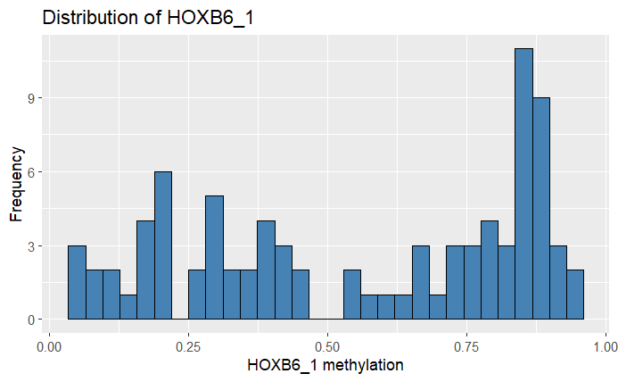

```r
library(ggplot2)

ggplot(df_finaal, aes(x = HOXB6_1)) +
  geom_histogram(bins = 30, fill = "steelblue", color = "black") +
  labs(
    title = "Distribution of HOXB6_1",
    x = "HOXB6_1 methylation",
    y = "Frequency"
  )
```

7.2 Violin plots

The violin plots illustrate the full density distribution of the predictor for each outcome group.

7.2.1 HOXB6_1 violin plot

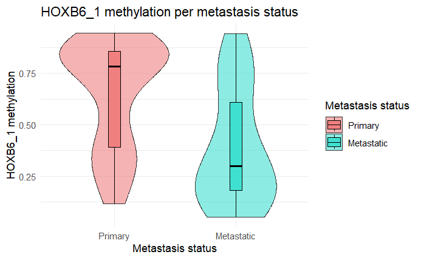

```r
ggplot(df_finaal, aes(x = factor(label_site_label), y = HOXB6_1, fill = factor(label_site_label))) +
  geom_violin(alpha = 0.6) +
  geom_boxplot(width = 0.1, color = "black") +
  scale_x_discrete(labels = c("0" = "Primary", "1" = "Metastatic")) +
  scale_fill_manual(values = c("0" = "lightcoral", "1" = "turquoise"),
                    labels = c("Primary", "Metastatic"), name = 'Metastasis status') +
  labs(
    title = "HOXB6_1 methylation per metastasis status",
    x = "Metastasis status",
    y = "HOXB6_1 methylation"
  ) +
  theme_minimal()
```

The violin plots reveal a clear difference between the two outcome groups, with metastatic colorectal cancer samples exhibiting significantly lower HOXB6_1 methylation compared to primary colorectal cancer samples.

7.2.2 Age violin plot

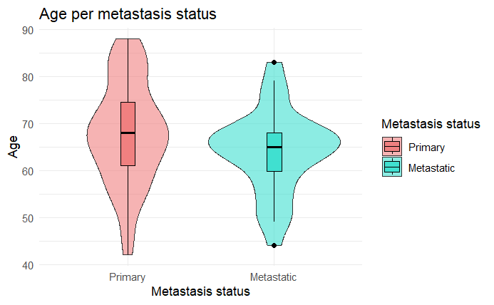

```r
ggplot(df_finaal, aes(x = factor(label_site_label), y = label_age, fill = factor(label_site_label))) +
geom_violin(alpha = 0.6) +
geom_boxplot(width = 0.1, color = "black") +
scale_x_discrete(labels = c("0" = "Primary", "1" = "Metastatic")) +
scale_fill_manual(values = c("0" = "lightcoral", "1" = "turquoise"),
labels = c("Primary", "Metastatic"),
name = 'Metastasis status') +
labs(
title = "Age per metastasis status",
x = "Metastasis status",
y = "Age"
) +
theme_minimal()
```

Both distributions display a similar shape and considerable overlap, reflecting the borderline significant p-value for label_age.

7.3 Heatmap

Lastly, a heatmap represents the predicted probability of metastasis based on HOXB6_1 methylation profile and age. We observe that the highest predicted probabilities of metastasis occur in younger patients with low HOXB6_1 methylation levels.

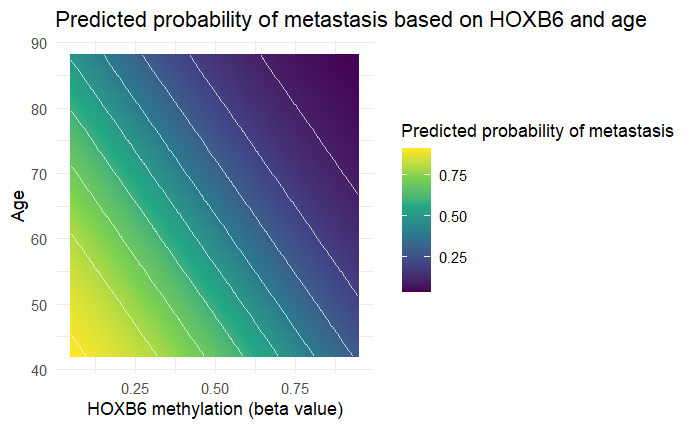

```r
plotdata <- expand.grid(
  HOXB6_1 = seq(min(df_finaal$HOXB6_1), max(df_finaal$HOXB6_1), length.out = 100),
  label_age = seq(min(df_finaal$label_age), max(df_finaal$label_age), length.out = 100)
)

plotdata$pred_prob <- predict(
  glm(label_site_label ~ label_age + HOXB6_1,
      family = binomial, data = df_finaal),
  newdata = plotdata, type = "response"
)

ggplot(plotdata, aes(x = HOXB6_1, y = label_age, z = pred_prob)) +
  geom_tile(aes(fill = pred_prob)) +
  geom_contour(color = "white", alpha = 0.7) +
  scale_fill_viridis_c(name = "Predicted probability of metastasis") +
  labs(
    x = "HOXB6 methylation (beta value)",
    y = "Age",
    title = "Predicted probability of metastasis based on HOXB6 and age"
  ) +
  theme_minimal()
```